# 1.4 — Data Wrangling in the tidyverse — R Practice (Answers)

ECON 480 — Fall 2021

Thursday, September 2, 2021

# Getting Set Up

Before we begin, start a new file with `File` $\rightarrow$ `New File` $\rightarrow$ `R Script`. As you work through this sheet in the console in `R`, also add (copy/paste) your commands that work into this new file. At the end, save it, and run to execute all of your commands at once.

First things first, load `tidyverse`.

```r
library("tidyverse")
```

# Warm Up to `dplyr` With `gapminder`

## 1.

#### Load `gapminder`. `select()` the variables `year`, `lifeExp`, `country`.

```r
library(gapminder)
# select(gapminder, c(year, lifeExp, country))

# using the pipe

gapminder %>%
  select(c(year, lifeExp, country))
```

| year | lifeExp | country |
| --- | --- | --- |
| 1952 | 28.80100 | Afghanistan |
| 1957 | 30.33200 | Afghanistan |
| 1962 | 31.99700 | Afghanistan |
| 1967 | 34.02000 | Afghanistan |
| 1972 | 36.08800 | Afghanistan |
| 1977 | 38.43800 | Afghanistan |
| 1982 | 39.85400 | Afghanistan |
| 1987 | 40.82200 | Afghanistan |
| 1992 | 41.67400 | Afghanistan |
| 1997 | 41.76300 | Afghanistan |

[output cut: 1694 more lines]

## 2.

#### `select()` all variables *except* `pop`.

```r
# select(gapminder, -pop)

# using the pipe

gapminder %>%
  select(-pop)
```

| country | continent | year | lifeExp | gdpPercap |
| --- | --- | --- | --- | --- |
| Afghanistan | Asia | 1952 | 28.80100 | 779.4453 |
| Afghanistan | Asia | 1957 | 30.33200 | 820.8530 |
| Afghanistan | Asia | 1962 | 31.99700 | 853.1007 |
| Afghanistan | Asia | 1967 | 34.02000 | 836.1971 |
| Afghanistan | Asia | 1972 | 36.08800 | 739.9811 |
| Afghanistan | Asia | 1977 | 38.43800 | 786.1134 |
| Afghanistan | Asia | 1982 | 39.85400 | 978.0114 |
| Afghanistan | Asia | 1987 | 40.82200 | 852.3959 |
| Afghanistan | Asia | 1992 | 41.67400 | 649.3414 |
| Afghanistan | Asia | 1997 | 41.76300 | 635.3414 |

[output cut: 1694 more lines]

## 3.

#### `rename()` `continent` to `cont`.

```r
# rename(gapminder, cont=continent)

# using the pipe

gapminder %>%
  rename(cont=continent)
```

| country | cont | year | lifeExp | pop | gdpPercap |
| --- | --- | --- | --- | --- | --- |
| Afghanistan | Asia | 1952 | 28.80100 | 8425333 | 779.4453 |
| Afghanistan | Asia | 1957 | 30.33200 | 9240934 | 820.8530 |
| Afghanistan | Asia | 1962 | 31.99700 | 10267083 | 853.1007 |
| Afghanistan | Asia | 1967 | 34.02000 | 11537966 | 836.1971 |
| Afghanistan | Asia | 1972 | 36.08800 | 13079460 | 739.9811 |
| Afghanistan | Asia | 1977 | 38.43800 | 14880372 | 786.1134 |
| Afghanistan | Asia | 1982 | 39.85400 | 12881816 | 978.0114 |
| Afghanistan | Asia | 1987 | 40.82200 | 13867957 | 852.3959 |
| Afghanistan | Asia | 1992 | 41.67400 | 16317921 | 649.3414 |
| Afghanistan | Asia | 1997 | 41.76300 | 22227415 | 635.3414 |

[output cut: 1694 more lines]

## 4.

#### `arrange()` by year.

```r
# arrange(gapminder, year)

# with the pipe
gapminder %>%
  arrange(year)
```

| country | continent | year | lifeExp | pop | gdpPercap |
| --- | --- | --- | --- | --- | --- |
| Afghanistan | Asia | 1952 | 28.80100 | 8425333 | 779.4453 |
| Albania | Europe | 1952 | 55.23000 | 1282697 | 1601.0561 |
| Algeria | Africa | 1952 | 43.07700 | 9279525 | 2449.0082 |
| Angola | Africa | 1952 | 30.01500 | 4232095 | 3520.6103 |
| Argentina | Americas | 1952 | 62.48500 | 17876956 | 5911.3151 |
| Australia | Oceania | 1952 | 69.12000 | 8691212 | 10039.5956 |
| Austria | Europe | 1952 | 66.80000 | 6927772 | 6137.0765 |
| Bahrain | Asia | 1952 | 50.93900 | 120447 | 9867.0848 |
| Bangladesh | Asia | 1952 | 37.48400 | 46886859 | 684.2442 |
| Belgium | Europe | 1952 | 68.00000 | 8730405 | 8343.1051 |

[output cut: 1694 more lines]

## 5.

#### `arrange()` by year, but in descending order.

```r
# arrange(gapminder, desc(year))

# with the pipe
gapminder %>%
  arrange(desc(year))
```

| country | continent | year | lifeExp | pop | gdpPercap |
| --- | --- | --- | --- | --- | --- |
| Afghanistan | Asia | 2007 | 43.82800 | 31889923 | 974.5803 |
| Albania | Europe | 2007 | 76.42300 | 3600523 | 5937.0295 |
| Algeria | Africa | 2007 | 72.30100 | 33333216 | 6223.3675 |
| Angola | Africa | 2007 | 42.73100 | 12420476 | 4797.2313 |
| Argentina | Americas | 2007 | 75.32000 | 40301927 | 12779.3796 |
| Australia | Oceania | 2007 | 81.23500 | 20434176 | 34435.3674 |
| Austria | Europe | 2007 | 79.82900 | 8199783 | 36126.4927 |
| Bahrain | Asia | 2007 | 75.63500 | 708573 | 29796.0483 |
| Bangladesh | Asia | 2007 | 64.06200 | 150448339 | 1391.2538 |
| Belgium | Europe | 2007 | 79.44100 | 10392226 | 33692.6051 |

[output cut: 1694 more lines]

## 6.

#### `arrange()` by year, then by life expectancy.

```r
# arrange(gapminder, year, lifeExp)

# with the pipe

gapminder %>%
  arrange(year, lifeExp)
```

| country | continent | year | lifeExp | pop | gdpPercap |
| --- | --- | --- | --- | --- | --- |
| Afghanistan | Asia | 1952 | 28.80100 | 8425333 | 779.4453 |
| Gambia | Africa | 1952 | 30.00000 | 284320 | 485.2307 |
| Angola | Africa | 1952 | 30.01500 | 4232095 | 3520.6103 |
| Sierra Leone | Africa | 1952 | 30.33100 | 2143249 | 879.7877 |
| Mozambique | Africa | 1952 | 31.28600 | 6446316 | 468.5260 |
| Burkina Faso | Africa | 1952 | 31.97500 | 4469979 | 543.2552 |
| Guinea-Bissau | Africa | 1952 | 32.50000 | 580653 | 299.8503 |
| Yemen, Rep. | Asia | 1952 | 32.54800 | 4963829 | 781.7176 |
| Somalia | Africa | 1952 | 32.97800 | 2526994 | 1135.7498 |
| Guinea | Africa | 1952 | 33.60900 | 2664249 | 510.1965 |

[output cut: 1694 more lines]

## 7.

#### `filter()` observations with `pop` greater than 1 billion.

```r
# arrange(filter, pop>1000000000)

# with the pipe

gapminder %>%
  filter(pop>1000000000)
```

| country | continent | year | lifeExp | pop | gdpPercap |
| --- | --- | --- | --- | --- | --- |
| China | Asia | 1982 | 65.525 | 1000281000 | 962.4214 |
| China | Asia | 1987 | 67.274 | 1084035000 | 1378.9040 |
| China | Asia | 1992 | 68.690 | 1164970000 | 1655.7842 |
| China | Asia | 1997 | 70.426 | 1230075000 | 2289.2341 |
| China | Asia | 2002 | 72.028 | 1280400000 | 3119.2809 |
| China | Asia | 2007 | 72.961 | 1318683096 | 4959.1149 |
| India | Asia | 2002 | 62.879 | 1034172547 | 1746.7695 |
| India | Asia | 2007 | 64.698 | 1110396331 | 2452.2104 |

## 8.

#### Of those, look only at `India`.

```r
gapminder %>%
  filter(pop>1000000000) %>%
  filter(country=="India")
```

| country | continent | year | lifeExp | pop | gdpPercap |
| --- | --- | --- | --- | --- | --- |
| India | Asia | 2002 | 62.879 | 1034172547 | 1746.769 |
| India | Asia | 2007 | 64.698 | 1110396331 | 2452.210 |

## 9.

#### Try out the pipe (`%>%`) if you haven’t already, by chaining commands: `select()` your data to look only at `year`, `gdpPercap`, and `country` in the year `1997`, for countries that have a `gdpPercap` greater than 20,000, and `arrange()` them alphabetically.

```r
gapminder %>%
  select(year, gdpPercap, country) %>%
  filter(year==1997,
         gdpPercap>20000) %>%
  arrange(country)
```

| year | gdpPercap | country |
| --- | --- | --- |
| 1997 | 26997.94 | Australia |
| 1997 | 29095.92 | Austria |
| 1997 | 20292.02 | Bahrain |
| 1997 | 27561.20 | Belgium |
| 1997 | 28954.93 | Canada |
| 1997 | 29804.35 | Denmark |
| 1997 | 23723.95 | Finland |
| 1997 | 25889.78 | France |
| 1997 | 27788.88 | Germany |
| 1997 | 28377.63 | Hong Kong, China |

[output cut: 17 more lines]

## 10.

#### `mutate()` a new variable called `GDP` that is equal to `gdpPercap * pop`.

```r
gapminder %>%
  mutate(GDP = gdpPercap * pop)
```

| country | continent | year | lifeExp | pop | gdpPercap | GDP |
| --- | --- | --- | --- | --- | --- | --- |
| Afghanistan | Asia | 1952 | 28.80100 | 8425333 | 779.4453 | 6.567086e+09 |
| Afghanistan | Asia | 1957 | 30.33200 | 9240934 | 820.8530 | 7.585449e+09 |
| Afghanistan | Asia | 1962 | 31.99700 | 10267083 | 853.1007 | 8.758856e+09 |
| Afghanistan | Asia | 1967 | 34.02000 | 11537966 | 836.1971 | 9.648014e+09 |
| Afghanistan | Asia | 1972 | 36.08800 | 13079460 | 739.9811 | 9.678553e+09 |
| Afghanistan | Asia | 1977 | 38.43800 | 14880372 | 786.1134 | 1.169766e+10 |
| Afghanistan | Asia | 1982 | 39.85400 | 12881816 | 978.0114 | 1.259856e+10 |
| Afghanistan | Asia | 1987 | 40.82200 | 13867957 | 852.3959 | 1.182099e+10 |
| Afghanistan | Asia | 1992 | 41.67400 | 16317921 | 649.3414 | 1.059590e+10 |
| Afghanistan | Asia | 1997 | 41.76300 | 22227415 | 635.3414 | 1.412200e+10 |

[output cut: 1694 more lines]

## 11.

#### `mutate()` a new population variable that is the `pop` in millions.

```r
gapminder %>%
  mutate(popm = pop/1000000)
```

| country | continent | year | lifeExp | pop | gdpPercap | popm |
| --- | --- | --- | --- | --- | --- | --- |
| Afghanistan | Asia | 1952 | 28.80100 | 8425333 | 779.4453 | 8.425333 |
| Afghanistan | Asia | 1957 | 30.33200 | 9240934 | 820.8530 | 9.240934 |
| Afghanistan | Asia | 1962 | 31.99700 | 10267083 | 853.1007 | 10.267083 |
| Afghanistan | Asia | 1967 | 34.02000 | 11537966 | 836.1971 | 11.537966 |
| Afghanistan | Asia | 1972 | 36.08800 | 13079460 | 739.9811 | 13.079460 |
| Afghanistan | Asia | 1977 | 38.43800 | 14880372 | 786.1134 | 14.880372 |
| Afghanistan | Asia | 1982 | 39.85400 | 12881816 | 978.0114 | 12.881816 |
| Afghanistan | Asia | 1987 | 40.82200 | 13867957 | 852.3959 | 13.867957 |
| Afghanistan | Asia | 1992 | 41.67400 | 16317921 | 649.3414 | 16.317921 |
| Afghanistan | Asia | 1997 | 41.76300 | 22227415 | 635.3414 | 22.227415 |

[output cut: 1694 more lines]

## 12.

#### `summarize()` to get the average GDP per capita.

```r
gapminder %>%
  summarize(mean(gdpPercap))
```

| mean(gdpPercap) |
| --- |
| 7215.327 |

## 13.

#### Get the number of observations, average, minimum, maximum, and standard deviation for GDP per capita.

```r
gapminder %>%
  summarize(Obs = n(),
            Average = mean(gdpPercap),
            Minimum = min(gdpPercap),
            Maximum = max(gdpPercap),
            SD = sd(gdpPercap))
```

| Obs | Average | Minimum | Maximum | SD |
| --- | --- | --- | --- | --- |
| 1704 | 7215.327 | 241.1659 | 113523.1 | 9857.455 |

## 14.

#### Get the average GDP per capita over time. Hint, first `group_by()` year.

```r
gapminder %>%
  group_by(year) %>%
  summarize(Average_GDP = mean(gdpPercap))
```

| year | Average_GDP |
| --- | --- |
| 1952 | 3725.276 |
| 1957 | 4299.408 |
| 1962 | 4725.812 |
| 1967 | 5483.653 |
| 1972 | 6770.083 |
| 1977 | 7313.166 |
| 1982 | 7518.902 |
| 1987 | 7900.920 |
| 1992 | 8158.609 |
| 1997 | 9090.175 |

[output cut: 2 more lines]

## 15.

#### Get the average GDP per capita by continent.

```r
gapminder %>%
  group_by(continent) %>%
  summarize(Average_GDP = mean(gdpPercap))
```

| continent | Average_GDP |
| --- | --- |
| Africa | 2193.755 |
| Americas | 7136.110 |
| Asia | 7902.150 |
| Europe | 14469.476 |
| Oceania | 18621.609 |

## 16.

#### Get the average GDP per capita by year and by continent.[^1] Then save this as another `tibble` called `gdp`. Create a `ggplot` of a `line` graph of average continent GDP over time using the `gdp` data.

```r
gdp <- gapminder %>%
  group_by(year, continent) %>%
  summarize(Average_GDP = mean(gdpPercap))
```

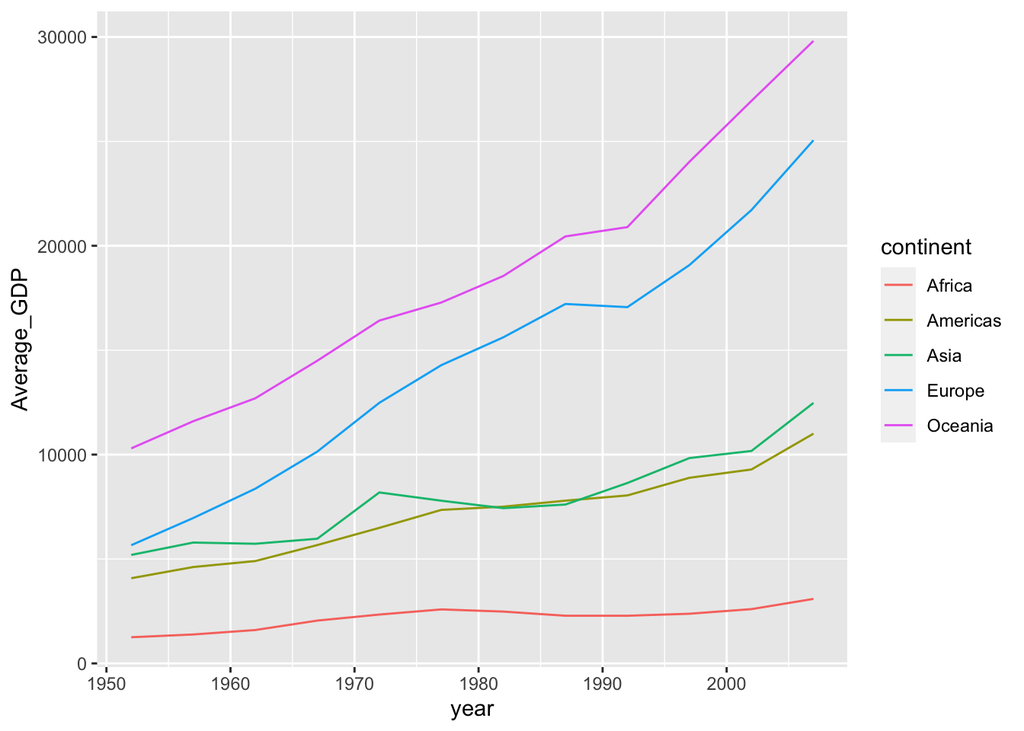

```r
ggplot(data = gdp)+
  aes(x = year,
      y = Average_GDP,
      color = continent)+
  geom_line()
```

## 17.

#### Try it again all in one command with the pipe `%>%`. Instead of saving the data as `gdp`, pipe it right into `ggplot`![^2]

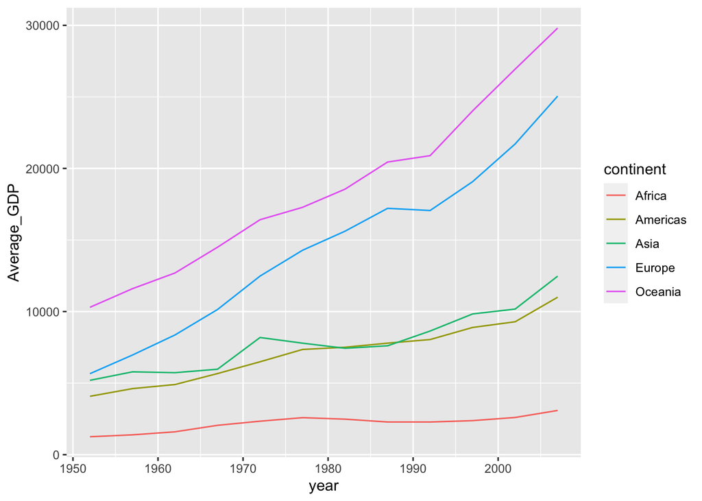

```r
gapminder %>%
  group_by(year, continent) %>%
  summarize(Average_GDP = mean(gdpPercap)) %>%
ggplot(data = .)+
  aes(x = year,
      y = Average_GDP,
      color = continent)+
  geom_line()
```

# Example I: Majors

Now let’s step it up to work with some data “in the wild” to answer some research questions. This will have you combine your `dplyr` skills and add some new things such as importing with `readr`.

Let’s look at fivethirtyeight’s article [" The Economic Guide To Picking A College Major "](https://fivethirtyeight.com/features/the-economic-guide-to-picking-a-college-major/). fivethirtyeight is great about making the data behind their articles public, we can [download all of their data here](https://data.fivethirtyeight.com/). Search for `college majors` and click download (the blue arrow button).[^3] We will look at the `recent-grads.csv` file.

The description in the `readme` file for the data is as follows:

| Header | Description |
| --- | --- |
| `Rank` | Rank by median earnings |
| `Major_code` | Major code, FO1DP in ACS PUMS |
| `Major` | Major description |
| `Major_category` | Category of major from Carnevale et al |
| `Total` | Total number of people with major |
| `Sample_size` | Sample size (unweighted) of full-time, year-round ONLY (used for earnings) |
| `Men` | Male graduates |
| `Women` | Female graduates |
| `ShareWomen` | Women as share of total |
| `Employed` | Number employed (ESR == 1 or 2) |
| `Full_time` | Employed 35 hours or more |
| `Part_time` | Employed less than 35 hours |
| `Full_time_year_round` | Employed at least 50 weeks (WKW == 1) and at least 35 hours (WKHP >= 35) |
| `Unemployed` | Number unemployed (ESR == 3) |
| `Unemployment_rate` | Unemployed / (Unemployed + Employed) |
| `Median` | Median earnings of full-time, year-round workers |
| `P25th` | 25th percentile of earnigns |
| `P75th` | 75th percentile of earnings |
| `College_jobs` | Number with job requiring a college degree |
| `Non_college_jobs` | Number with job not requiring a college degree |
| `Low_wage_jobs` | Number in low-wage service jobs |

## 18.

#### Import the data with `read_csv()` and assign it to `tibble` called `majors`.[^4] The first argument of this command the name of the original file, in quotes.[^5]

```r
majors<-read_csv("../data/recent-grads.csv") # note my location on my computer is different than yours!
```

# Wrangling Data (with `dplyr`)

## 19.

#### Look at the data with `glimpse()`. This is a suped-up version of `str()` in `tidyverse`.

```r
glimpse(majors)
```

```
## Rows: 173
## Columns: 21
## $ Rank                 <dbl> 1, 2, 3, 4, 5, 6, 7, 8, 9, 10, 11, 12, 13, 14, 15…
## $ Major_code           <dbl> 2419, 2416, 2415, 2417, 2405, 2418, 6202, 5001, 2…
## $ Major                <chr> "PETROLEUM ENGINEERING", "MINING AND MINERAL ENGI…
## $ Total                <dbl> 2339, 756, 856, 1258, 32260, 2573, 3777, 1792, 91…
## $ Men                  <dbl> 2057, 679, 725, 1123, 21239, 2200, 2110, 832, 803…
## $ Women                <dbl> 282, 77, 131, 135, 11021, 373, 1667, 960, 10907, …
## $ Major_category       <chr> "Engineering", "Engineering", "Engineering", "Eng…
## $ ShareWomen           <dbl> 0.1205643, 0.1018519, 0.1530374, 0.1073132, 0.341…
## $ Sample_size          <dbl> 36, 7, 3, 16, 289, 17, 51, 10, 1029, 631, 399, 14…
## $ Employed             <dbl> 1976, 640, 648, 758, 25694, 1857, 2912, 1526, 764…
## $ Full_time            <dbl> 1849, 556, 558, 1069, 23170, 2038, 2924, 1085, 71…
## $ Part_time            <dbl> 270, 170, 133, 150, 5180, 264, 296, 553, 13101, 1…
## $ Full_time_year_round <dbl> 1207, 388, 340, 692, 16697, 1449, 2482, 827, 5463…
## $ Unemployed           <dbl> 37, 85, 16, 40, 1672, 400, 308, 33, 4650, 3895, 2…
## $ Unemployment_rate    <dbl> 0.018380527, 0.117241379, 0.024096386, 0.05012531…
## $ Median               <dbl> 110000, 75000, 73000, 70000, 65000, 65000, 62000,…
## $ P25th                <dbl> 95000, 55000, 50000, 43000, 50000, 50000, 53000, …
## $ P75th                <dbl> 125000, 90000, 105000, 80000, 75000, 102000, 7200…
## $ College_jobs         <dbl> 1534, 350, 456, 529, 18314, 1142, 1768, 972, 5284…
## $ Non_college_jobs     <dbl> 364, 257, 176, 102, 4440, 657, 314, 500, 16384, 1…
## $ Low_wage_jobs        <dbl> 193, 50, 0, 0, 972, 244, 259, 220, 3253, 3170, 98…
```

## 20.

#### What are all of the unique values of `Major`? How many are there?

```r
majors %>%
  distinct(Major)
```

| Major |
| --- |
| PETROLEUM ENGINEERING |
| MINING AND MINERAL ENGINEERING |
| METALLURGICAL ENGINEERING |
| NAVAL ARCHITECTURE AND MARINE ENGINEERING |
| CHEMICAL ENGINEERING |
| NUCLEAR ENGINEERING |
| ACTUARIAL SCIENCE |
| ASTRONOMY AND ASTROPHYSICS |
| MECHANICAL ENGINEERING |
| ELECTRICAL ENGINEERING |

[output cut: 163 more lines]

```r
majors %>%
  summarize(n_distinct(Major))
```

| n_distinct(Major) |
| --- |
| 173 |

## 21.

#### Which major has the lowest unemployment rate?

```r
majors %>%
  arrange(Unemployment_rate) %>%
  select(Major, Unemployment_rate)
```

| Major | Unemployment_rate |
| --- | --- |
| MATHEMATICS AND COMPUTER SCIENCE | 0.000000000 |
| MILITARY TECHNOLOGIES | 0.000000000 |
| BOTANY | 0.000000000 |
| SOIL SCIENCE | 0.000000000 |
| EDUCATIONAL ADMINISTRATION AND SUPERVISION | 0.000000000 |
| ENGINEERING MECHANICS PHYSICS AND SCIENCE | 0.006334343 |
| COURT REPORTING | 0.011689692 |
| MATHEMATICS TEACHER EDUCATION | 0.016202835 |
| PETROLEUM ENGINEERING | 0.018380527 |
| GENERAL AGRICULTURE | 0.019642463 |

[output cut: 163 more lines]

## 22.

#### What are the top 3 majors that have the highest percentage of women?

```r
majors %>%
  arrange(desc(ShareWomen)) %>%
  select(Major, ShareWomen) %>%
  slice(1:3) # head(., n=3) also works
```

| Major | ShareWomen |
| --- | --- |
| EARLY CHILDHOOD EDUCATION | 0.9689537 |
| COMMUNICATION DISORDERS SCIENCES AND SERVICES | 0.9679981 |
| MEDICAL ASSISTING SERVICES | 0.9278072 |

## 23.

#### Make a boxplot of `Median` wage by `Major_Category`.[^6]

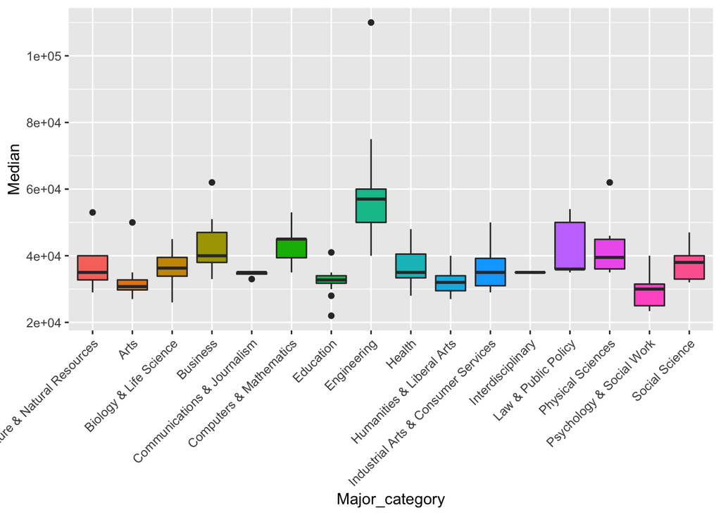

```r
ggplot(data = majors)+
  aes(x = Major_category,
      y = Median,
      fill = Major_category)+
  geom_boxplot()+
  theme(axis.text.x=element_text(angle=45, hjust=1), legend.position = "")
```

## 24.

#### Which major category is the least popular in this sample?[^7]

```r
majors %>%
  group_by(Major_category) %>%
  count() %>%
  arrange(n)
```

| Major_category | n |
| --- | --- |
| Interdisciplinary | 1 |
| Communications & Journalism | 4 |
| Law & Public Policy | 5 |
| Industrial Arts & Consumer Services | 7 |
| Arts | 8 |
| Psychology & Social Work | 9 |
| Social Science | 9 |
| Agriculture & Natural Resources | 10 |
| Physical Sciences | 10 |
| Computers & Mathematics | 11 |

[output cut: 6 more lines]

## 25.

#### Is there a systematic difference between STEM majors and non-STEM majors? First define:

```r
stem_categories <- c("Biology & Life Science",
                     "Computers & Mathematics",
                     "Engineering",
                     "Physical Sciences")
```

Next, make a variable `stem`, for whether or not a `Major_category` is `"stem"` or `"not_stem"`.[^8]

```r
majors <- majors %>%
  mutate(stem = ifelse(Major_category %in% stem_categories,
                       "stem",
                       "not_stem")) %>%
  select(stem, everything()) # just so we can see it up front to verify
```

Then `summarize()` `median` for stem and not stem groups.

```r
majors %>%
  group_by(stem) %>%
  summarize(mean(Median))
```

| stem | mean(Median) |
| --- | --- |
| not_stem | 35624.77 |
| stem | 47860.94 |

[^1]: Hint: do `year` first, if you do `continent` first, there are no years to group by!
[^2]: Hint: You can use `.` as a placeholder.
[^3]: This will download a `.zip` file that contains many spreadsheets. Unzip it with a program that unzips files (such as WinZip, 7-zip, the Unarchiver, etc).
[^4]: One way to avoid error messages is to move it to the same file as R’s working directory, which again you can determine with `getwd()`.
[^5]: If the file is in a different folder, the argument is the full path in quotes.
[^6]: You won’t be able to read the labels easily, so add `theme(axis.text.x=element_text(angle=45, hjust=1)` to angle `x`-axis labels (and move them down by 1)
[^7]: Hint: use `group_by` first.
[^8]: Hint: try out the `ifelse()` function which has three inputs: condition(s) for a variable(s), what to do if `TRUE` (the if), and what to if `FALSE` (the else).